# US Flights Data Analysis

## by Thays Martinez

## Investigation Overview

The goal of this investigation is to understand the characteristics that most influence flights delay duration.

## Dataset Overview

Due to the large volume of data, the analysis was done on a sample dataset of approximately 500,000 US flights recorded from January 2015 until December 2019. The attributes include scheduled departure/arrival date and times, actual departure/arrival times, arrival delay duration, taxi-in and taxi out duration as well as the reported causes of cancellation or delay. Although a small proportion of flights was either cancelled or recorded extremely long delays, no data points were removed from the dataset, they were rather analysed separately.

## Distribution of Flight Outcomes

Flight types are classified as Cancelled, Delayed (if delay duration is equal or above 15 minutes) or On-time. Data suggests that 80.2% of flights between 2015 and 2019 are considered to arrive on time. Delays account for 18.3%, and 1.5% of flights were cancelled.

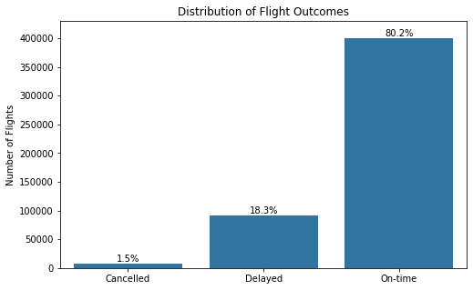

```python
plt.figure(figsize=[8, 5])
sb.countplot(data=flights, x='fl_type', color=base_color)
chart_props(flights, 'fl_type')
plt.xlabel('')
plt.ylabel('Number of Flights')
plt.ylim(0, 430000)
plt.title('Distribution of Flight Outcomes');
```

## Distribution of Flight Delay Duration

Departure and arrival delay variables have a long-tailed distribution, with a lot of flights actually departing and arriving ahead or on time, and fewer flights on the high delay end.

Interestingly, there are two larger spikes just before the 0-min delay mark in the departure delay graph, showing that to a great degree, actual departure times follow the scheduled time. On the other hand, distribution in the arrival delay duration are more spread out to both sides of the 0-min delay mark, with a less accentuated peak.

Both distributions suggests that (1) to some degree actual departure times can affect actual arrival times both positively and negatively, and in the occurrence of the latter (2) actual departure times may be compensated by managing runaway throughput at the destination, flight schedules, taxiing upon arrival, etc.

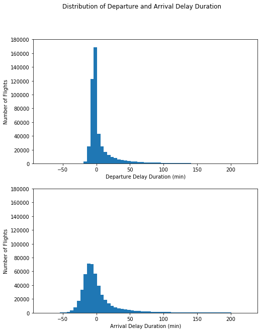

```python
max_delay = flights['arr_delay'].max()
min_delay = flights['arr_delay'].min()
bin_edges = np.arange(min_delay, max_delay+5, 5)

fig, ax = plt.subplots(nrows = 2, figsize = [8, 10])

ax[0].hist(data=flights, x='dep_delay', bins=bin_edges)
ax[0].set_xlim(min_delay, 240)
ax[0].set_ylim(0, 180000)
ax[0].set_xlabel('Departure Delay Duration (min)')
ax[0].set_ylabel('Number of Flights');

ax[1].hist(data=flights, x='arr_delay', bins=bin_edges)
ax[1].set_xlim(min_delay, 240)
ax[1].set_ylim(0, 180000)
ax[1].set_xlabel('Arrival Delay Duration (min)')
ax[1].set_ylabel('Number of Flights')
fig.suptitle('Distribution of Departure and Arrival Delay Duration');
```

## Distribution of Taxi-out and Taxi-in Duration

Taxi-out time is defined as the time between the actual pushback and wheels-off. Also here the chart shows a long-tail distribution with some points taking unusually high values. To focus on the bulk of the distribution, limits to the x-axis were applied.

Aircraft taxiing duration on departure has a wider distribution, with most flights taking between 10 to 20 minutes to taxi.

There is a narrower distribution in taxiing times at arrival with most flights taking between 0 to 10 minutes, which suggests that airport operators try to compensate long taxi-out times and/or delays by adjusting schedule, gates assignment and/or controlling taxi speed at arrival.

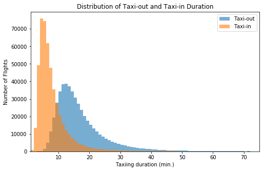

```python
min_taxi = flights.taxi_out.min()
max_taxi = flights.taxi_out.max()
bin_edges = np.arange(min_taxi, max_taxi+1, 1)
plt.figure(figsize=[8, 5])

plt.hist(data=flights, x='taxi_out', bins=bin_edges, alpha=0.6, label='Taxi-out')
plt.hist(data=flights, x='taxi_in', bins=bin_edges, alpha=0.6, label='Taxi-in')
plt.xlim(min_taxi, 75)
plt.xlabel('Taxiing duration (min.)')
plt.ylabel('Number of Flights')
plt.title('Distribution of Taxi-out and Taxi-in Duration')
plt.legend(loc='upper right')
plt.show()
```

## Flight Outcome vs. Year and Month

Zooming into month's data, cancelled flights didn't suffer significant variations. On the other hand, there is a noticeable increase in delayed flights for the months of June, July and August, and another peak for December. The peak for On-time flights occurred for the month of October, whereas February seems to record the lowest level on average.

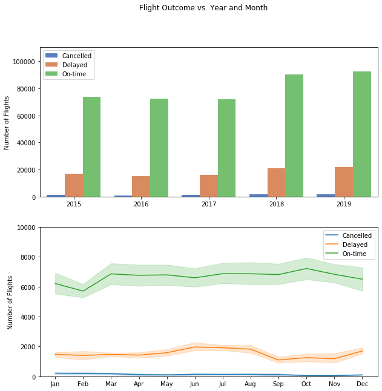

```python
df_types = flights.groupby(['year', 'month', 'fl_type']).fl_type.count()
df_types = df_types.reset_index(name='count')

plt.figure(figsize=[10, 10])

ax = plt.subplot(2, 1, 1)
sb.countplot(data=flights, x='year', hue='fl_type', palette='muted');
plt.ylim(0, 110000) # Set y-axis limit to fit legend
plt.ylabel('Number of Flights')
plt.xlabel('')
ax.legend(loc=2);

ax = plt.subplot(2, 1, 2)
sb.lineplot(data = df_types, x = 'month', y='count', hue='fl_type', legend='full')
plt.ylim(0, 10000)
plt.ylabel('Number of Flights')
plt.xlabel('')
ax.legend(loc=2); # Set y-axis limit to fit legend
handles, labels = ax.get_legend_handles_labels()
ax.legend(handles=handles[1:], labels=labels[1:])
plt.suptitle('Flight Outcome vs. Year and Month');
```

## Flight Delay vs. Delay Reason

According to the [Bureau of Transportation and Statistics](https://www.bts.gov/topics/airlines-and-airports/understanding-reporting-causes-flight-delays-and-cancellations), airlines report the causes of delay in broad categories that were created by the Air Carrier On-Time Reporting Advisory Committee.

The categories are:

- **Air Carrier**: The cause of the cancellation or delay was due to circumstances within the airline's control (e.g. maintenance or crew problems, aircraft cleaning, baggage loading, fueling, etc.).
- **Extreme Weather**: Significant meteorological conditions (actual or forecasted) that, in the judgment of the carrier, delays or prevents the operation of a flight such as tornado, blizzard or hurricane.
- **National Aviation System (NAS)**: Delays and cancellations attributable to the national aviation system that refer to a broad set of conditions, such as non-extreme weather conditions, airport operations, heavy traffic volume, and air traffic control.
- **Late-arriving aircraft**: A previous flight with same aircraft arrived late, causing the present flight to depart late.
- **Security**: Delays or cancellations caused by evacuation of a terminal or concourse, re-boarding of aircraft because of security breach, inoperative screening equipment and/or long lines in excess of 29 minutes at screening areas.

The longest average delay occurred due to weather - which in this dataset took on average 56 minutes. These are especially harder to manage due to its uncontrollable nature. The second longest delay type was Late Aircraft, followed by Carrier, NAS and Security, which on average took less than 30 minutes.

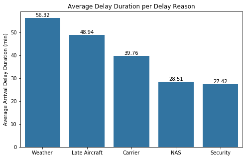

```python
data = melt_delay.groupby(['delay_desc']).delay_dur.mean()
data = data.reset_index().sort_values('delay_dur', ascending=False)

plt.figure(figsize=[8, 5])
sb.barplot(data=data, x='delay_desc', y='delay_dur', color=base_color)
chart_means(data, 'delay_desc')
plt.xlabel('')
plt.ylabel('Average Arrival Delay Duration (min)')
plt.title('Average Delay Duration per Delay Reason');
```

## Average Arrival Delay per Year and Month

The average arrival delay varied between 54 and 77 minutes. In general, June, July, August, December and January are the months when average delay is higher. Again here a higher average delay is also observed in the years 2018 and 2019.

Additionally, when comparing 2018 and 2019, average delay increased in all months, except for September, which remained the same: 65 minutes.

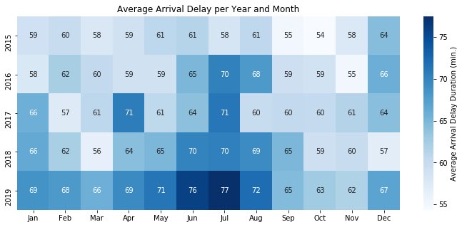

```python
data = delays.groupby(['year', 'month']).arr_delay.mean()
data = data.reset_index(name='avg_delay')
data = data.pivot('year', 'month', 'avg_delay')

plt.figure(figsize=(12, 5))
sb.heatmap(data, cmap='Blues', annot=True, cbar_kws={'label': 'Average Arrival Delay Duration (min.)'})
plt.title('Average Arrival Delay per Year and Month')
plt.xlabel('')
plt.ylabel('');
```

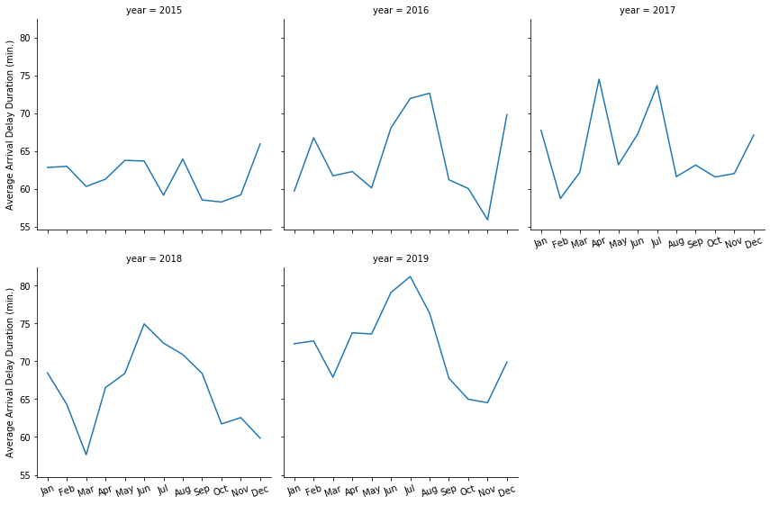

```python
g = sb.FacetGrid(data=melt_delay, col='year', height=4, col_wrap=3)
g.map(sb.lineplot, 'month', 'arr_delay', ci=None)
g.set_xticklabels(rotation=20)
g.set(xlabel='', ylabel='Average Arrival Delay Duration (min.)');
```

## Average Arrival Delay per Month and Scheduled Departure Time

Fleet traffic are concentrated between 6am and 10pm, suggesting that airports limit their operation hours due to noise pollution regulations. Consequenyly, the plot was limited to show flight's delays from this time window only. Flights scheduled to depart at 6am seems to have the highest average delay overall. During the months of June, July and August, flights with schedule departure times between 5pm and 8pm also had higher delays on average.

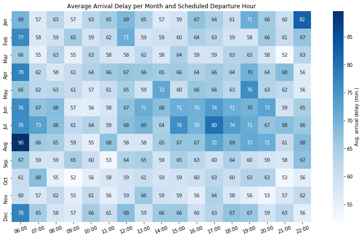

```python
op_hours = ['23:00', '00:00', '01:00', '02:00', '03:00', '04:00', '05:00']
op_hours = [str(item).zfill(2) for item in op_hours]
data = delays.query('crs_dep_time not in @op_hours')

data = data.groupby(['month', 'crs_dep_time']).arr_delay.mean()
data = data.reset_index(name='avg_delay')
data = data.pivot('month', 'crs_dep_time', 'avg_delay')

plt.figure(figsize=(16, 8))
sb.heatmap(data, cmap='Blues', square=True, annot=True,
           cbar_kws={'label': 'Avg. arrival delay (min.)'})
plt.title('Average Arrival Delay per Month and Scheduled Departure Hour')
plt.xlabel('')
plt.ylabel('')
plt.xticks(rotation=20);
```

## Flight Delay vs. Delay Severity

Delayed flights have been categorized according to its severity:

- **Short**: 15 - 60 min.
- **Medium**: 61 - 150 min.
- **Long**: 151 - 330 min.
- **Severe**: above 330 min.

Short-delay flights are almost 3 times more frequent than medium-delays, and together both represent 92% of the delayed flights in the dataset analyzed. Long and severe delays account for only 8% of the delayed flights. Since these categories aggregate just a few flighs with extended delay duration, any calculation using average delay may not be representative of the whole dataset.

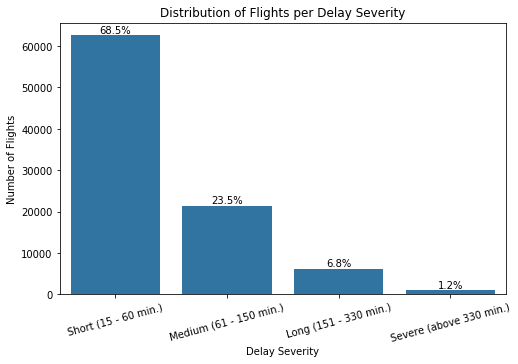

```python
plt.figure(figsize=[8, 5])
sb.countplot(data=delays, x='delay_severity', color=base_color)
chart_props(delays, 'delay_severity')
plt.ylabel('Number of Flights')
plt.xlabel('Delay Severity')
plt.title('Distribution of Flights per Delay Severity')
plt.xticks(rotation=15);
```

## Top 10 Airports per Fleet Traffic

### Focus on Flights with up to 2.5 hours delay

Because most of delays fall into Short and Medium severity, I'm interested in finding out which are the top 10 airports per fleet trafic that had up to 2.5 hours delay.

Nearly 35% of flights are concentrated in 10 airports. O'Hare International Airport (ORD) recorded 15.6% of flights throughout the 5-year period, whereas McCarran International Airport (LAS), Phoenix Sky Harbor International Airport (PHX) and George Bush Intercontinental Airport (IAH) had approximately 7% of flights during the same period.

```
Delayed flights (all airports): 91316
Delayed flights (top 10 airports): 31210 (34.0%)
```

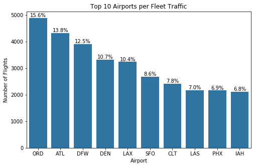

```python
order_airpt = data.dep_airport.value_counts().index

plt.figure(figsize=[8, 5])
sb.countplot(data=data, x='dep_airport', color=base_color, order=order_airpt)
chart_props(data, 'dep_airport')
plt.title('Top 10 Airports per Fleet Traffic')
plt.ylabel('Number of Flights')
plt.xlabel('Airport');

total_delays = len(delays)
top10_delays = len(data)
top10_pct = round(len(data)/len(delays)*100, 0)

print('Delayed flights (all airports): {}'.format(total_delays))
print('Delayed flights (top 10 airports): {} ({}%)'.format(top10_delays, top10_pct))
```

## Average Delay Duration per Delay Category and Departure Airport

According to the definition, delays due to Late aircraft occur when a previous flight with same aircraft arrived late, causing the present flight to depart late. Due to the ripple effect in the subsequent stages of a flight, one can expect that cummulative delays are harder to compensate, thus the highest average.

The violin plots also shows that delays due to Security reasons are fewer than other types of delays. Denver International Airport (DEN) recorded only one flight delay in this category, and Los Angeles International Airport (LAX) has the highest average delay in this category: close to 50 minutes.

ORD registered a high variability in Carrier, Wheather, NAS and Late Aircraft, as opposed to delays due to Security which concentrated between 10 - 25 minutes.

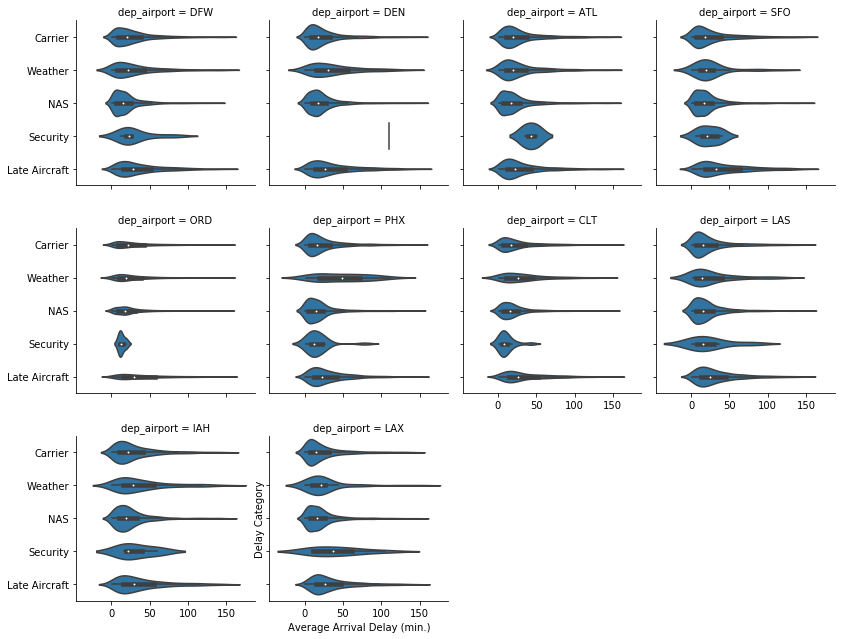

```python
# Generate plot
# plt.figure(figsize=[12, 12]);
g = sb.FacetGrid(data = data_melt, col = 'dep_airport', col_wrap=4, sharey=True)
g.map(sb.violinplot, 'delay_dur', 'delay_desc')
g.set(xlabel='', ylabel='')
plt.ylabel('Delay Category')
plt.xlabel('Average Arrival Delay (min.)');
```

## What is the average delay duration the top 10 airports recorded during airport operation hours?

The highest average delay duration was registered for LAS at 6am. There is also another peak of 96 minutes average for San Francisco International Airport (SFO) at 8pm.

The highest average arrival time seems to occur at different times of the day for each airport. Those tend to be concentrated between 3pm and 10pm.

The plot also suggests that ORD and SFO have the highest average delays throughout the entire operation period.

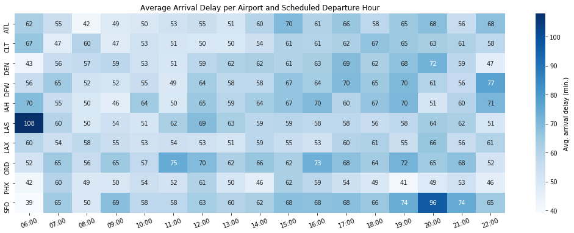

```python
airpt_severity = delays.query('dep_airport in @top10_airpt & crs_dep_time not in @op_hours')


airpt_hour = airpt_severity.groupby(['dep_airport', 'crs_dep_time']).arr_delay.mean()
airpt_hour = airpt_hour.reset_index(name='avg_delay')
airpt_hour = airpt_hour.pivot('dep_airport', 'crs_dep_time', 'avg_delay')

plt.figure(figsize=(18, 6))
sb.heatmap(airpt_hour, cmap='Blues', annot=True, fmt='.0f',
           cbar_kws={'label': 'Avg. arrival delay (min.)'})
plt.title('Average Arrival Delay per Airport and Scheduled Departure Hour')
plt.xlabel('')
plt.ylabel('')
plt.xticks(rotation=20);
```

## What about taxi-out average duration?

Flights departing at 8am tends to have the highest taxi-out duration, and the lowest average taxi-out duration occurs in the evening, between 5 and 10pm.

Also here we can see that ORD and SFO have the highest average taxi-out duration throughout the whole operation window.

From the top 10, PHX had the lowest average, ranging between 13 and 25, having its highest taxi-out duration between 7 and 11am.

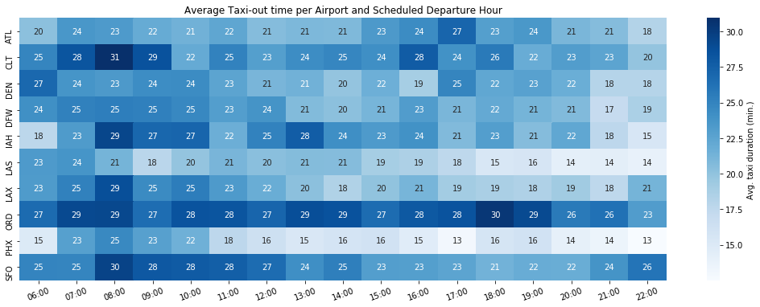

```python
fl_taxi = airpt_severity.groupby(['dep_airport', 'crs_dep_time']).taxi_out.mean()
fl_taxi = fl_taxi.reset_index(name='avg_taxi')
fl_taxi = fl_taxi.pivot('dep_airport', 'crs_dep_time', 'avg_taxi')

plt.figure(figsize=(18, 6))
sb.heatmap(fl_taxi, cmap='Blues', annot=True,
           cbar_kws={'label': 'Avg. taxi duration (min.)'})
plt.title('Average Taxi-out time per Airport and Scheduled Departure Hour')
plt.xlabel('')
plt.ylabel('')
plt.xticks(rotation=20);
```